```r
library(tidyverse)
library(data.table)
library(randomForest)
set.seed(1)
mail <- fread('mail_order.csv')
# mail
training_idx <- 1:2000
training <- mail[training_idx,]
testing <- mail[-training_idx,]
```

- 총 4000개의 데이터 중 처음 2000개 데이터를 훈련 데이터로 사용하고, 나머지 2000개를 테스트 데이터로 활용했으며 모든 문제에 대해 같게 적용했습니다.
- 임의추출을 필요로 하는 내용이 있어 결과의 일관성을 위해 set.seed를 1로 주었습니다.
- 이후에 사용된 코드는 보고서의 방향성을 고려할 때 굳이 적을 필요가 없다 판단되어 표시하지 않았습니다. 코드를 보여줄 필요성이 있는 경우 가장 마지막에 주석처럼 표시하도록 하겠습니다.

# Question 1.

Randomly select 500 customers in the validation sample. Calculate the number of customers who actually made purchases. (This is the baseline case. That is, it represents the hit rate without employing models.)

```
## [1] 0.064
```

- 기준 점수는 0.064 (6.4%)입니다.

# Question 2.

Create 222 RFM codes for estimation and validation sample. Note that the median of recency, 0.5(recency) is 12, 0.5(frequency) is 2, and 0.5(monetary) = $209. Based on the RFM analysis of the estimation sample, select 500 customers (in the validation sample) with the highest purchase potentials. Calculate the number of customers who actually made purchases.

```
## # A tibble: 8 x 5
## # Groups:   R, F [4]
##       R     F     M     n  proba
##   <dbl> <dbl> <dbl> <int>  <dbl>
## 1     2     2     1   137 0.175
## 2     2     2     2   305 0.167
## 3     2     1     2   258 0.0891
## 4     2     1     1   393 0.0636
## 5     1     2     2   229 0.0611
## 6     1     2     1   119 0.0504
## 7     1     1     2   215 0.0465
## 8     1     1     1   344 0.0291
```

```
## # A tibble: 8 x 5
## # Groups:   R, F [4]
##       R     F     M     n  proba
##   <dbl> <dbl> <dbl> <int>  <dbl>
## 1     2     2     2   274 0.172
## 2     2     2     1   126 0.135
## 3     2     1     2   269 0.115
## 4     1     2     1   117 0.0940
## 5     1     2     2   250 0.068
## 6     2     1     1   413 0.0533
## 7     1     1     2   224 0.0402
## 8     1     1     1   327 0.0245
```

```
## [1] 76
```

```
## [1] 0.152
```

- 위의 테이블은 트레인셋을 RFM 기준으로 8 집단을 나눈 후 구매확률에 따라 정렬한 것이고, 아래 테이블은 테스트셋에서 각 RFM 집단마다 몇 명이 분포해 있는지 파악하고 총합이 500이 되게 하기 위해 표시한 결과입니다.
- 테스트셋에서 3번째 집단인 RFM이 2,1,2인 집단을 100명만 추출해야 했기 때문에 랜덤으로 100명을 선택했습니다.
- 결과는 선택한 500명 중 76명이 실제 구매를 했고, 비율은 0.152 (15.2%)이었습니다.

# Question 3.

Create 555 RFM codes for estimation and validation sample. Use the following rules that divide the sample into five (approximately) equal segments. Based on the RFM analysis of the estimation sample, select 500 customers (in the validation sample) with the highest purchase potentials. Calculate the number of customers who actually made purchases.

```
## # A tibble: 1 x 3
##       n purchase proba
##   <int>    <int> <dbl>
## 1   500       62 0.124
```

- 2번 문제와 비슷하게 수행한 결과 선택한 500명 중 62명이 구매를 해 확률은 0.124 (12.4%)였습니다.
- 8개 집단으로 나눈 것에 비해 125개 집단으로 나누면서 예측률이 더 떨어진 것을 통해 집단을 더 많이 나누는 것이 꼭 더 좋은 결과를 불러오지 않는다는 것을 알 수 있었습니다.

# Question 4.

Apply the following linear regression model to the estimation sample. Purchase = 0 + 1(recency) + 2(frequency) + 3(monetary) Based on the coefficient estimates from the regression, estimate the purchase probability of each of 2,000 customers in the validation sample. Select the top 500 customers and calculate the number of customers who actually made purchases.

```
## # A tibble: 1 x 2
##   purchase_num purchase_prob
##          <int>         <dbl>
## 1           80          0.16
```

- 2, 3번 문제와 달리 인위적으로 그룹화를 해주지 않고 recency, frequency, monetary 변수 자체를 가지고 회귀분석을 수행하였고, 학습한 계수를 테스트셋에 적용하여 가장 값이 높게 예측되는 것부터 500개를 순서대로 선별하였습니다.
- 선택한 500개에서 실제 구매는 80명이 했고, 이는 0.16 (16%)에 해당하는 수치입니다.
- 로지스틱 회귀분석을 수행할 경우 하려는 목적에 더 맞을 것으로 예상되어 로짓 확률로 정렬 후 가장 확률이 높은 500개 수행한 결과의 확률은 16.6%였습니다.

# Question 5.

Propose a model of any form and do the same as above. (Your model will be evaluated in terms of the magnitude of improvement over the above models in validation sample.)

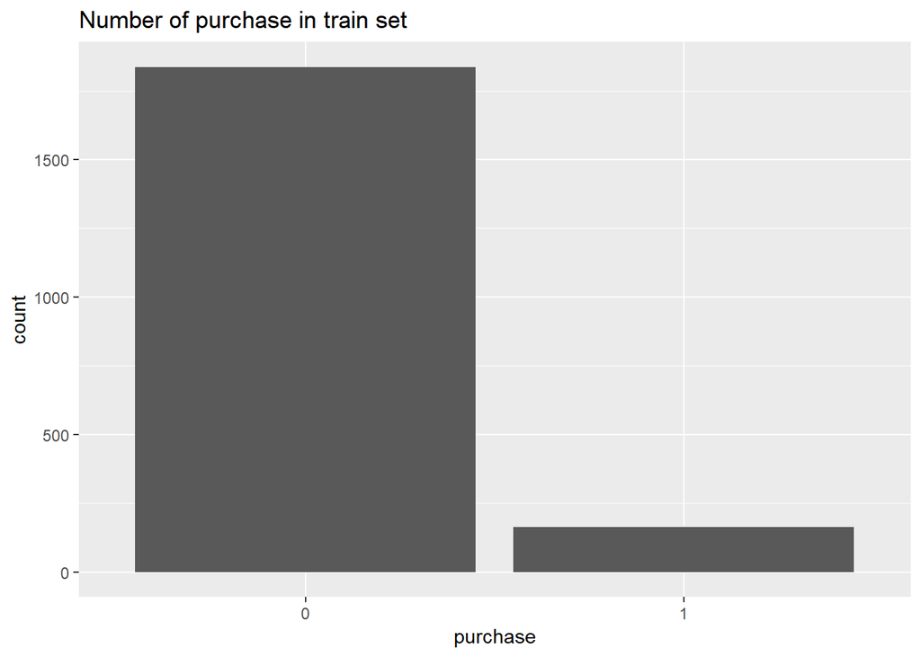

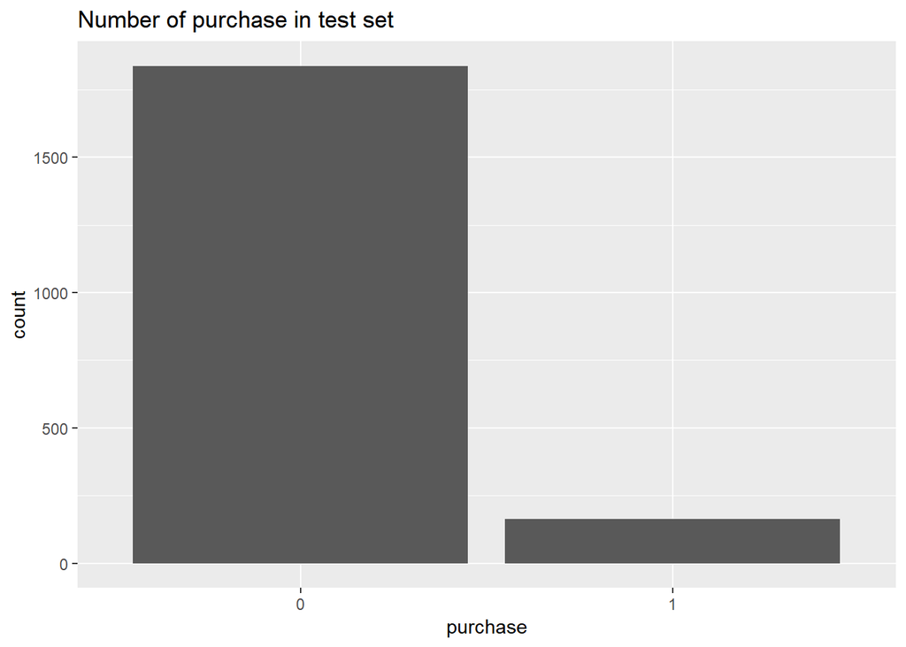

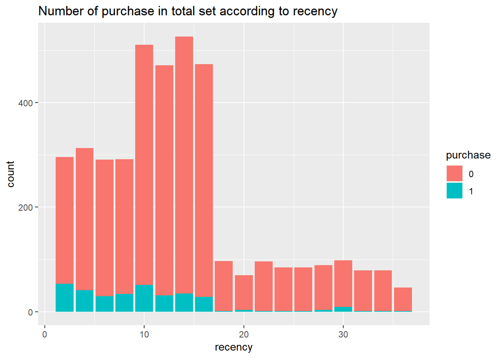

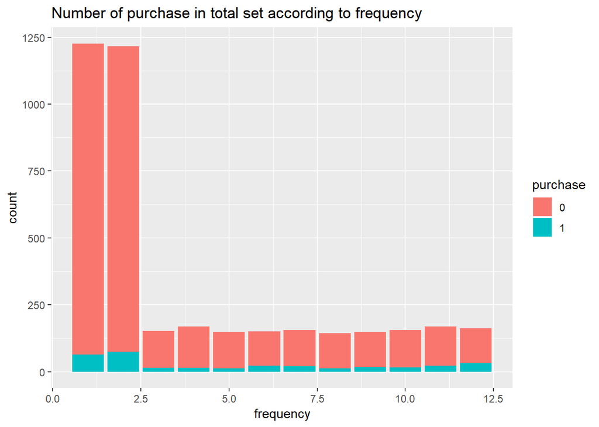

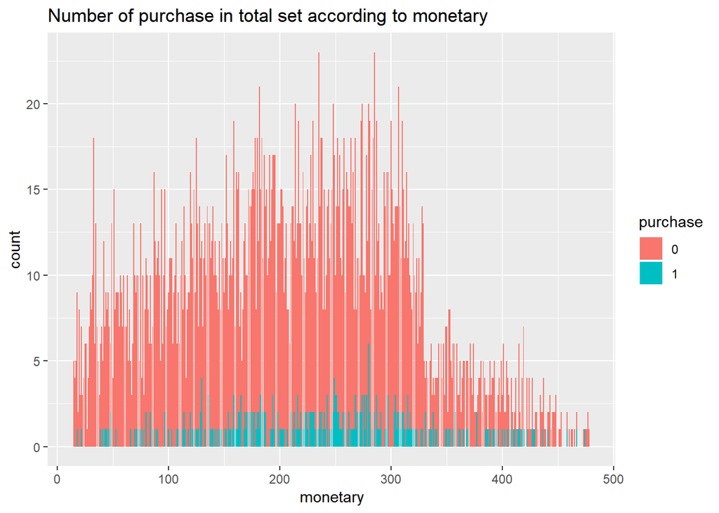

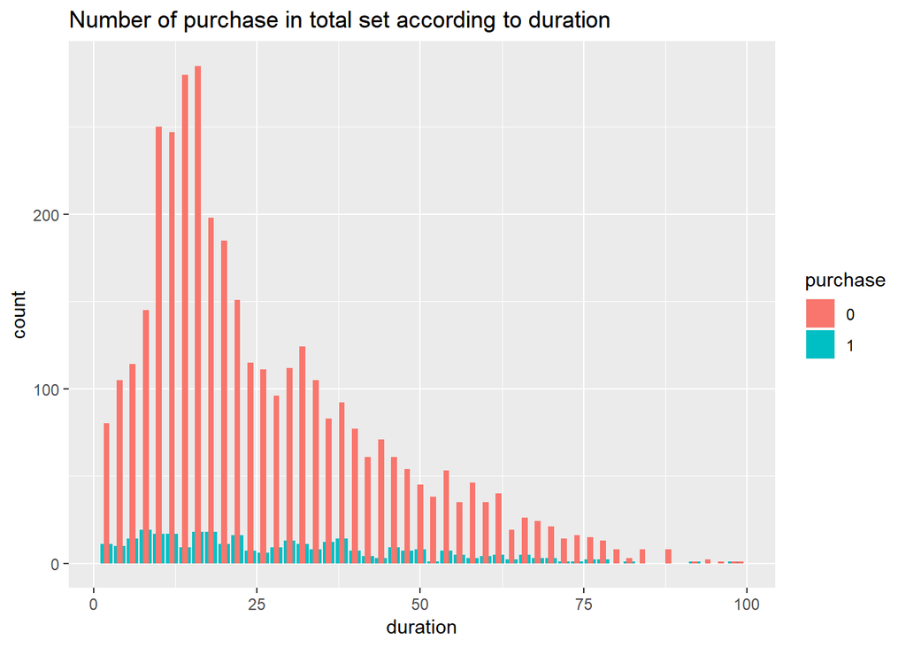

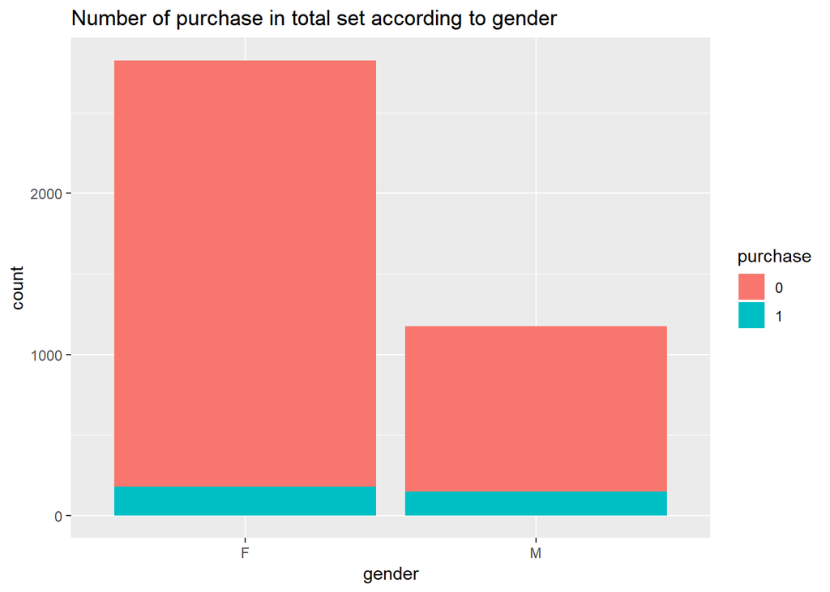

```
##         glm.pred
## purchase    0
##        0 1838
##        1  162
```

```
##
## Call:
## glm(formula = purchase ~ gender + recency + frequency, family = "binomial",
##     data = train)
##
## Deviance Residuals:
##     Min       1Q   Median       3Q      Max
## -0.9994  -0.4412  -0.3492  -0.2651   3.0044
##
## Coefficients:
##             Estimate Std. Error z value Pr(>|z|)
## (Intercept) -2.26279    0.19811 -11.422  < 2e-16 ***
## genderM      0.64005    0.17166   3.729 0.000193 ***
## recency     -0.07697    0.01315  -5.853 4.82e-09 ***
## frequency    0.11187    0.02098   5.332 9.71e-08 ***
## ---
## Signif. codes:  0 '***' 0.001 '**' 0.01 '*' 0.05 '.' 0.1 ' ' 1
##
## (Dispersion parameter for binomial family taken to be 1)
##
##     Null deviance: 1129.7  on 1999  degrees of freedom
## Residual deviance: 1048.2  on 1996  degrees of freedom
## AIC: 1056.2
##
## Number of Fisher Scoring iterations: 6
```

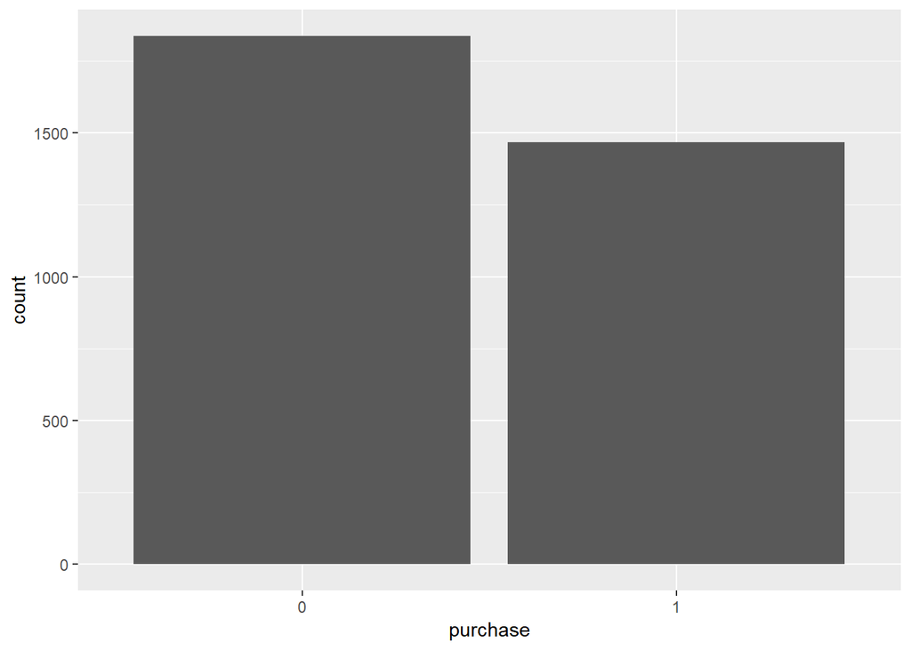

```
##         glm.pred
## purchase    0    1
##        0 1693  145
##        1  123   39
```

```
##
## Call:
## glm(formula = purchase ~ gender + monetary + recency + frequency,
##     family = "binomial", data = Ntrain)
##
## Deviance Residuals:
##     Min       1Q   Median       3Q      Max
## -1.8896  -1.0130  -0.6624   1.1185   2.3174
##
## Coefficients:
##               Estimate Std. Error z value Pr(>|z|)
## (Intercept) -0.3923012  0.1119389  -3.505 0.000457 ***
## genderM      0.6781879  0.0793818   8.543  < 2e-16 ***
## monetary     0.0018251  0.0004259   4.286 1.82e-05 ***
## recency     -0.0696135  0.0052766 -13.193  < 2e-16 ***
## frequency    0.0734325  0.0105577   6.955 3.52e-12 ***
## ---
## Signif. codes:  0 '***' 0.001 '**' 0.01 '*' 0.05 '.' 0.1 ' ' 1
##
## (Dispersion parameter for binomial family taken to be 1)
##
##     Null deviance: 4538.8  on 3303  degrees of freedom
## Residual deviance: 4134.0  on 3299  degrees of freedom
## AIC: 4144
##
## Number of Fisher Scoring iterations: 4
```

```
## [1] 0.2119565
```

```
## [1] 0.866
```